# Cinema Project - Conjoint Analysis

Elena Costagliola & Dario Fabiani

18/02/2021

```r
library(mlogit)
library(MASS)
library(lattice)
library(corrplot)
library(ggplot2)
library(patchwork)
library(dplyr)

source("conj_functions.R")
```

# 1 Introduction

In recent years, major changes are taking place in the market with the increasing digitalization of its sectors. There are new ways of conceiving and enjoying cinema, mainly based on streaming. For years now, the cinema sector has been subjected to competition from new platforms, with decreasing earnings. Although there are those who argue that the comparison between streaming and cinema is unfounded, it is inevitable that the way of conceiving cinema should at least be brought up to date. The unparalleled cinema experience cannot disappear but, especially with the current pandemic, allowing cinemas to earn from streaming would be a way to reinvigorate the industry.

For this reason we tried to think of a cinema offer in symbiosis with the streaming trend, which would allow the customer to choose cinema passes that include 4, 7 or 10 movies of the Commercial, Independent or Animation genres. The movies can be enjoyed both in theaters and in streaming in a fixed time slot, and are proposed with video quality proportional to the unit price of the pass.

Hence, our *research question* is: “Which kind of pass can revive the cinema sector in this pandemic period?”.

Starting from this perspective, we designed a survey with the aim of assessing which type of cinema pass would be most appealing.

Our survey has 6 attributes, each attribute is divided into 3 levels: Number of movies, Type of movie, Time slot, Quality of the streaming, Quality of Cinema and Price; the variable Quality of the streaming, instead, ha only has only 2 levels.

The final survey consisted of 18 questions, which we divided between two different Google Forms distributed via QR codes, messages and social networks. The total number of people reached was 141. The experimental design used to develop the survey and the specific means used to collect the responses will be discussed in more detail in the section on data collection.

Once we had all the responses, we wrote a python script to convert the output of the Google form into a long format readable for the packages of the Choice-based Conjoint analysis. We opted for this type of Conjoint analysis because it better mimics what the consumers actually do when they buy: choosing among alternatives is a more natural activity.

In the Data Analysis section we analyze the responses obtained. In particular, we manage the analysis firstly with an MNL model that do not consider the heterogeneity among the respondents. Then we fit three mixed MNL models to deal with heterogeneity. The first model assumes no correlation between variables, the second model assumes correlation between all variables and the third one assumes correlation only between variables with significant correlation. We eased the interpretation of data computing **willingness-to-pay** and **preference shares**. With them we were able to identify the best average pass, the one that combines a high number of movie, a Commercial type and evening shows. In addition, we focus on studying the heterogeneity of attribute level distributions distinguishing homogeneous from heterogeneous distributions. In the latter we try, successfully, to identify niches. We opted for a careful interpretation, setting a threshold to 20% to assess there was a niche, and we found some potential niches of customers for the attribute level `3D` and `Animazione.`

# 2 Data Collection

In building our survey we were constrained by the huge number of combinations that our alternatives and levels could give. Therefore, to avoid a high dropout rate, we took advantage of the *orthogonal main-effect fractional factorial design*, which gave us a subset of the design that was enough to estimate the part-worth coefficients for the main effects. This design method is based on *orthogonality*: it avoids under or over representation since all the levels of attributes have the same frequency. However, the use of this method prevented us from assessing all the interaction effects. The alternative to this approach would have been the D-optimal of the Optimal design, which would have given us better results in term of accuracy, but we would have had to specify the a-priori distribution of parameters. Since we had no a priori knowledge about the parameters, we opted for the fractional factorial design.

This gave us 18 choice sets including a total of 54 product profiles to evaluate, which is quite a high number for a single respondent. Therefore, we decided to divide the choice sets into two surveys which we distributed via two Google forms. To construct the choice sets we used the *mix-and-match* method.

The survey consists of 6 attributes with their respective levels, as follows:

- Number of movies has 3 levels: 4, 7, 10.
- Type of movie has 3 levels as well: Commercial, Independent and Animation.
- Time slot has 3 levels: morning (9-13), afternoon (15-19) and evening (21-24).
- Quality of the streaming has 2 levels: Full HD and 4K.
- Quality of the Cinema has 3 levels: Standard, IMAX and 3D.
- Price has 3 levels: 40, 60, 80.

In addition, we also included some individual-level variables: Age, Job and Gender.

Once the choice sets were generated through R, we entered them into readable tables[^1] and entered them into Google forms. At this point, we started distributing it. Given our means, the **sample is not representative**: we could not select people randomly and hence the sample cannot properly represent the population. First, we distributed it to the people in line waiting to enter the BUC library in Trento with a QR code to avoid any contact. Then, we shared it to our friends and colleagues by link, finally we created some Instagram Stories to share them on the social network. Overall, we collected 141 responses.

# 3 Data Preparation

In this part we are setting up the variables to perform the analysis.

```r
df <- read.csv('df_longformat.csv', sep = ',')
df <- df %>% rename("età" = "etÃ.", "genere" = "sesso" )
attach(df)

str(df)
```

```
## 'data.frame':    3807 obs. of  13 variables:
##  $ resp.id    : int  1 1 1 1 1 1 1 1 1 1 ...
##  $ domanda    : int  1 1 1 2 2 2 3 3 3 4 ...
##  $ profilo    : int  1 2 3 1 2 3 1 2 3 1 ...
##  $ n_film     : int  10 7 10 4 7 10 4 7 4 7 ...
##  $ tipo_film  : chr  "Commerciali" "Indipendenti" "Animazione" "Commerciali" ...
##  $ h          : chr  "21-24" "15-19" "21-24" "15-19" ...
##  $ qual_stream: chr  "FullHD" "4K" "FullHD" "FullHD" ...
##  $ qual_cine  : chr  "IMAX" "IMAX" "3D" "IMAX" ...
##  $ prezzo     : int  60 60 80 80 40 60 40 40 60 60 ...
##  $ scelta     : int  0 0 1 0 1 0 0 1 0 0 ...
##  $ professione: chr  "Studente" "Studente" "Studente" "Studente" ...
##  $ genere     : chr  "M" "M" "M" "M" ...
##  $ età        : chr  "22-25" "22-25" "22-25" "22-25" ...
```

Here we convert the variables into factors and decide what will be the reference level for the analysis. Among the variables of the survey there are also Individual-level variables that we are going to use in the last part of the analysis.

```r
# alternative-specific variables with common coefficients
df$tipo_film <- factor(df$tipo_film, levels = c('Commerciali','Indipendenti','Animazione'))
df$h <- factor(df$h, levels= c('9-13','15-19','21-24'))
df$qual_cine <- factor(df$qual_cine, levels= c('Standard','IMAX','3D'))
df$qual_stream <- factor(df$qual_stream, levels = c('FullHD','4K'))
df$profilo <- as.character(profilo)
df$prezzo <- as.factor(prezzo)
df$n_film <- as.factor(n_film)

# individual level variables
df$professione <- as.factor(professione)
df$età <- as.factor(età)
df$genere <- as.factor(genere)
```

## 3.1 Preliminary check

```r
str(df)
```

```
## 'data.frame':    3807 obs. of  13 variables:
##  $ resp.id    : int  1 1 1 1 1 1 1 1 1 1 ...
##  $ domanda    : int  1 1 1 2 2 2 3 3 3 4 ...
##  $ profilo    : chr  "1" "2" "3" "1" ...
##  $ n_film     : Factor w/ 3 levels "4","7","10": 3 2 3 1 2 3 1 2 1 2 ...
##  $ tipo_film  : Factor w/ 3 levels "Commerciali",..: 1 2 3 1 2 3 3 3 3 2 ...
##  $ h          : Factor w/ 3 levels "9-13","15-19",..: 3 2 3 2 3 1 3 2 2 2 ...
##  $ qual_stream: Factor w/ 2 levels "FullHD","4K": 1 2 1 1 2 1 2 2 2 1 ...
##  $ qual_cine  : Factor w/ 3 levels "Standard","IMAX",..: 2 2 3 2 3 1 2 1 3 2 ...
##  $ prezzo     : Factor w/ 3 levels "40","60","80": 2 2 3 3 1 2 1 1 2 2 ...
##  $ scelta     : int  0 0 1 0 1 0 0 1 0 0 ...
##  $ professione: Factor w/ 4 levels "Disoccupato",..: 4 4 4 4 4 4 4 4 4 4 ...
##  $ genere     : Factor w/ 3 levels "Altro","F","M": 3 3 3 3 3 3 3 3 3 3 ...
##  $ età        : Factor w/ 6 levels "18-21","22-25",..: 2 2 2 2 2 2 2 2 2 2 ...
```

```r
summary(df)
```

```
##     resp.id       domanda       profilo          n_film           tipo_film
##  Min.   :  1   Min.   :   1   Length:3807        4 :1314   Commerciali :1269
##  1st Qu.: 36   1st Qu.: 318   Class :character   7 :1239   Indipendenti:1299
##  Median : 71   Median : 635   Mode  :character   10:1254   Animazione  :1239
##  Mean   : 71   Mean   : 635
##  3rd Qu.:106   3rd Qu.: 952
##  Max.   :141   Max.   :1269
##      h        qual_stream      qual_cine    prezzo        scelta
##  9-13 :1269   FullHD:1866   Standard:1239   40:1254   Min.   :0.0000
##  15-19:1269   4K    :1941   IMAX    :1284   60:1269   1st Qu.:0.0000
##  21-24:1269                 3D      :1284   80:1284   Median :0.0000
##                                                       Mean   :0.3333
##                                                       3rd Qu.:1.0000
##                                                       Max.   :1.0000
##                 professione     genere        età
##  Disoccupato          :  81   Altro:  27   18-21: 432
##  Lavoratore Autonomo  : 270   F    :1863   22-25:2268
##  Lavoratore Dipendente:1350   M    :1917   26-30: 702
##  Studente             :2106                31-40: 135
##                                            41-50:  27
##                                            51+  : 243
```

Due to the structure of the dataframe, the summary is difficult to interpret. On an individual-level perspective, we note that most of the respondents are students or employees between 22 and 30 years old. To assess whether attributes are properly represented we use `xtabs` which tells us how many times each level of certain attributes has been chosen.

```r
xtabs(scelta ~ n_film, data=df)
```

```
## n_film
##   4   7  10
## 437 415 417
```

```r
xtabs(scelta ~ tipo_film, data=df)
```

```
## tipo_film
##  Commerciali Indipendenti   Animazione
##          431          495          343
```

```r
xtabs(scelta ~ h, data=df)
```

```
## h
##  9-13 15-19 21-24
##   223   378   668
```

```r
xtabs(scelta ~ qual_stream, data=df)
```

```
## qual_stream
## FullHD     4K
##    589    680
```

```r
xtabs(scelta ~ qual_cine, data=df)
```

```
## qual_cine
## Standard     IMAX       3D
##      429      418      422
```

```r
xtabs(scelta ~ prezzo, data=df)
```

```
## prezzo
##  40  60  80
## 548 396 325
```

```r
xtabs(scelta ~ professione, data= df)
```

```
## professione
##           Disoccupato   Lavoratore Autonomo Lavoratore Dipendente
##                    27                    90                   450
##              Studente
##                   702
```

```r
xtabs(scelta ~ età, data= df)
```

```
## età
## 18-21 22-25 26-30 31-40 41-50   51+
##   144   756   234    45     9    81
```

```r
xtabs(scelta ~ genere, data= df)
```

```
## genere
## Altro     F     M
##     9   621   639
```

# 4 Data Analysis

Since the variable `scelta` (choice) is a qualitative multinomial response variable with three levels, we will fit the data using the multinomial logit (from now on MNL) model and the mixed MNL model. The former assumes there is not consumer heterogeneity, the latter instead deals with it assigning a unique coefficient to each respondent.

Before applying the Multinomial logit model, we need to pass it through the `dfidx` function, since the observations are characterized by a combination of two indexes, in our case one nested (`resp.id` nests the `domanda` index) and one called `profilo`.

Then we can apply the mlogit function from the package *mlogit*. The response variable is `scelta` and all the 6 covariates are used to fit the full model.

```r
df.mlogit <- dfidx(df, idx = list(c("domanda", "resp.id"), "profilo"), drop.index=FALSE,shape = 'long',
                   levels=c("1","2","3"))

m1 <- mlogit(scelta ~ n_film + tipo_film + h + qual_cine + qual_stream + prezzo, data = df.mlogit)
summary(m1)
```

```
##
## Call:
## mlogit(formula = scelta ~ n_film + tipo_film + h + qual_cine +
##     qual_stream + prezzo, data = df.mlogit, method = "nr")
##
## Frequencies of alternatives:choice
##       1       2       3
## 0.36643 0.31363 0.31994
##
## nr method
## 5 iterations, 0h:0m:0s
## g'(-H)^-1g = 0.000206
## successive function values within tolerance limits
##
## Coefficients :
##                        Estimate Std. Error  z-value  Pr(>|z|)
## (Intercept):2         -0.021704   0.081243  -0.2672 0.7893526
## (Intercept):3         -0.122691   0.081527  -1.5049 0.1323453
## n_film7                0.532742   0.126380   4.2154 2.493e-05 ***
## n_film10               0.589823   0.129781   4.5448 5.500e-06 ***
## tipo_filmIndipendenti -0.175658   0.096263  -1.8248 0.0680348 .
## tipo_filmAnimazione   -0.858111   0.113603  -7.5536 4.241e-14 ***
## h15-19                 0.775159   0.123419   6.2807 3.370e-10 ***
## h21-24                 1.953711   0.114341  17.0867 < 2.2e-16 ***
## qual_cineIMAX          0.028994   0.096742   0.2997 0.7644041
## qual_cine3D           -0.378560   0.112621  -3.3614 0.0007756 ***
## qual_stream4K          0.081997   0.086800   0.9447 0.3448303
## prezzo60              -0.545369   0.097811  -5.5758 2.464e-08 ***
## prezzo80              -1.227657   0.106987 -11.4748 < 2.2e-16 ***
## ---
## Signif. codes:  0 '***' 0.001 '**' 0.01 '*' 0.05 '.' 0.1 ' ' 1
##
## Log-Likelihood: -1107.6
## McFadden R^2:  0.20373
## Likelihood ratio test : chisq = 566.8 (p.value = < 2.22e-16)
```

Despite part worths are on a logit (and so non intuitive) scale, it is possible to have an idea of the overall consumers preference for each attribute level compared to its reference level. In the fitted model almost all the attributes are statistically significant, except for some of the levels referring to video quality: `IMAX` and `4K`. We assume that these attributes are not significant since respondents did not evaluate the benefits of a higher video quality, probably because they are not familiar with these movies formats. Surprisingly, `3D` results significant with a negative estimated average part worth, suggesting that consumers prefer standard quality when choosing a movie pass profile and underlying its lack of popularity nowadays.

On the other hand, the attributes `h21-24` and `prezzo80` show the highest part worths in terms of order of magnitude. Indeed, respondents show a clear and strong preference for the time slot `h21-24` over the level `h9-13`. Similarly, there is a greater tendency to prefer an afternoon time slot than a morning one. As expected, the part worths referring to the attribute `prezzo80` is negative, suggesting the consumers’ attitude to prefer cheaper cinema passes. Indeed, also the level `prezzo60` has a smaller but still negative coefficient.

With regard to movie genres the part worths indicate that, on average, there is a preference for commercial movies. The coefficient of animation movies is noteworthy as negative and quite high. It might be interesting to observe whether there is a niche of consumers interested in this kind of movie. As far as independent films are concerned, on the other hand, the low significance of the part worth will lately force us to be more cautious in our conclusions.

As expected, consumers preferred profiles containing a higher number of movies supporting the thesis that consumers would choose services that offer the most at the minimum price.

The fact that intercepts are not significant allows us to exclude the hypothesis that respondents made their choice based on the position of the alternatives. Therefore, we can try to get more precise estimates (gaining degrees of freedom) and to improve the model by fitting a *restricted model* without the intercepts (asc).

To assess the goodness of fit of models we used the *Likelihood ratio test* and, since the model is nested, the *Wald test*.

```r
m2 <- mlogit(scelta ~ n_film + tipo_film + h + qual_cine + qual_stream + prezzo |-1, data = df.mlogit)
summary(m2)
```

```
##
## Call:
## mlogit(formula = scelta ~ n_film + tipo_film + h + qual_cine +
##     qual_stream + prezzo | -1, data = df.mlogit, method = "nr")
##
## Frequencies of alternatives:choice
##       1       2       3
## 0.36643 0.31363 0.31994
##
## nr method
## 5 iterations, 0h:0m:0s
## g'(-H)^-1g = 8.17E-05
## successive function values within tolerance limits
##
## Coefficients :
##                        Estimate Std. Error  z-value  Pr(>|z|)
## n_film7                0.523438   0.125797   4.1610 3.169e-05 ***
## n_film10               0.604682   0.128806   4.6945 2.672e-06 ***
## tipo_filmIndipendenti -0.181759   0.095619  -1.9009  0.057318 .
## tipo_filmAnimazione   -0.839806   0.111445  -7.5356 4.863e-14 ***
## h15-19                 0.763031   0.122360   6.2360 4.490e-10 ***
## h21-24                 1.958054   0.112149  17.4594 < 2.2e-16 ***
## qual_cineIMAX          0.020969   0.096142   0.2181  0.827344
## qual_cine3D           -0.364870   0.111615  -3.2690  0.001079 **
## qual_stream4K          0.087996   0.086198   1.0209  0.307319
## prezzo60              -0.527335   0.097347  -5.4171 6.059e-08 ***
## prezzo80              -1.232079   0.107119 -11.5020 < 2.2e-16 ***
## ---
## Signif. codes:  0 '***' 0.001 '**' 0.01 '*' 0.05 '.' 0.1 ' ' 1
##
## Log-Likelihood: -1108.9
```

```r
lrtest(m1,m2)
```

|  | #Df | LogLik | Df | Chisq | Pr(>Chisq) |
| --- | --- | --- | --- | --- | --- |
| 1 | 13 | -1107.620 | NA | NA | NA |
| 2 | 11 | -1108.927 | -2 | 2.614152 | 0.2706101 |

```r
waldtest(m1,m2)
```

|  | Res.Df | Df | Chisq | Pr(>Chisq) |
| --- | --- | --- | --- | --- |
| 1 | 1256 | NA | NA | NA |
| 2 | 1258 | -2 | 2.590429 | 0.2738391 |

Both tests do not provide enough evidence to reject the null hypothesis, thus we can state that the restricted model is adequate to model the data. Therefore, the alternative specific constants are not significant and can be excluded.

When commenting part worths of the full model we have highlighted the difficulty of their interpretation. This can be eased by calculating the willingness to pay and preference shares.

## 4.1 Willingness to pay

To compute the willingness to pay, we need to convert price from factor to *quantitative* value. As a side effect, this conversion will also allow to gain degrees of freedom and to reduce standard errors.

```r
m3 <- mlogit(scelta ~ n_film + tipo_film + h + qual_cine + qual_stream + as.numeric(as.character(prezzo)) |-1, data = df.mlogit)
summary(m3)
```

```
##
## Call:
## mlogit(formula = scelta ~ n_film + tipo_film + h + qual_cine +
##     qual_stream + as.numeric(as.character(prezzo)) | -1, data = df.mlogit,
##     method = "nr")
##
## Frequencies of alternatives:choice
##       1       2       3
## 0.36643 0.31363 0.31994
##
## nr method
## 5 iterations, 0h:0m:0s
## g'(-H)^-1g = 8.66E-05
## successive function values within tolerance limits
##
## Coefficients :
##                                    Estimate Std. Error  z-value  Pr(>|z|)
## n_film7                           0.5158909  0.1255447   4.1092 3.970e-05 ***
## n_film10                          0.5835840  0.1263826   4.6176 3.882e-06 ***
## tipo_filmIndipendenti            -0.1719298  0.0949514  -1.8107 0.0701852 .
## tipo_filmAnimazione              -0.8393452  0.1109612  -7.5643 3.908e-14 ***
## h15-19                            0.7703618  0.1228895   6.2687 3.640e-10 ***
## h21-24                            1.9564790  0.1125284  17.3865 < 2.2e-16 ***
## qual_cineIMAX                     0.0134668  0.0955107   0.1410 0.8878720
## qual_cine3D                      -0.3876999  0.1095396  -3.5394 0.0004011 ***
## qual_stream4K                     0.0819706  0.0860502   0.9526 0.3407974
## as.numeric(as.character(prezzo)) -0.0304202  0.0026383 -11.5303 < 2.2e-16 ***
## ---
## Signif. codes:  0 '***' 0.001 '**' 0.01 '*' 0.05 '.' 0.1 ' ' 1
##
## Log-Likelihood: -1109.4
```

In this case we cannot apply a *Wald test*, since the models are not nested as in the previous case. Therefore, we test the goodness of fit of the new model using the *Likelihood ratio test*.

```r
lrtest(m2,m3)
```

|  | #Df | LogLik | Df | Chisq | Pr(>Chisq) |
| --- | --- | --- | --- | --- | --- |
| 1 | 11 | -1108.927 | NA | NA | NA |
| 2 | 10 | -1109.414 | -1 | 0.9734944 | 0.3238102 |

Again, there is not enough evidence to reject the null hypothesis. Hence, we can use the model with price as quantitative and compute the *Willingness-to-pay* for the model parameters.

```r
coef(m3)
```

```
##                          n_film7                         n_film10
##                       0.51589091                       0.58358400
##            tipo_filmIndipendenti              tipo_filmAnimazione
##                      -0.17192976                      -0.83934517
##                           h15-19                           h21-24
##                       0.77036179                       1.95647904
##                    qual_cineIMAX                      qual_cine3D
##                       0.01346676                      -0.38769992
##                    qual_stream4K as.numeric(as.character(prezzo))
##                       0.08197063                      -0.03042018
```

```r
prezzo_qnt <- (coef(m3)["as.numeric(as.character(prezzo))"])

WTP_df <- data.frame( "WTP"= c(coef(m3)["n_film7"]/prezzo_qnt,
                              coef(m3)["n_film10"]/prezzo_qnt,
                              coef(m3)["tipo_filmIndipendenti"]/prezzo_qnt,
                              coef(m3)["tipo_filmAnimazione"]/prezzo_qnt,
                              coef(m3)["h15-19"]/prezzo_qnt,
                              coef(m3)["h21-24"]/prezzo_qnt,
                              coef(m3)["qual_cineIMAX"]/prezzo_qnt,
                              coef(m3)["qual_cine3D"]/prezzo_qnt,
                              coef(m3)["qual_stream4K"]/prezzo_qnt))
WTP_df
```

|  | WTP |
| --- | --- |
| n_film7 | -16.9588355 |
| n_film10 | -19.1841043 |
| tipo_filmIndipendenti | 5.6518315 |
| tipo_filmAnimazione | 27.5917182 |
| h15-19 | -25.3240339 |
| h21-24 | -64.3151596 |
| qual_cineIMAX | -0.4426917 |
| qual_cine3D | 12.7448247 |
| qual_stream4K | -2.6946130 |

The results of the ratios give an idea (based on the survey data) of how much respondents would be willing to pay to be indifferent between the attribute level and the reference one. The most impressive values is represented by the level `h21-24`. On average, indeed, to make respondents indifferent between a morning and an evening pass the price would have to be reduced by 64€. This means that if a cinema wanted to increase the sale of morning passes, it would have to reduce the average price by more than 64€. Similarly, the average price of the pass with commercial movies would have to be at least 27€ higher to sell a pass containing animation movies. Thus a respondent would be willing to pay 27€ more to see a commercial movie over animation. It is worth of notice that respondents would pay from almost 17€ to 19€ less if they have to choose between 4 movies and 7 or 10. Moreover they would pay 12€ more to be indifferent between standard and 3D movie formats.

## 4.2 Simulate Preference Shares

Given the results above, we tried to evaluate which profiles would be the most preferable. Thus we selected 6 reasonable and economically viable product profiles (2 for each type of movie) and use them as a simulation of a market environment. This allowed us to compute *preference shares*.

```r
attributes <- list(n_film=names(table(df.mlogit$n_film)),
                   tipo_film=names(table(df.mlogit$tipo_film)),
                   h=names(table(df.mlogit$h)),
                   qual_stream=names(table(df.mlogit$qual_stream)),
                   qual_cine=names(table(df.mlogit$qual_cine)),
                   prezzo=names(table(df.mlogit$prezzo)))

# all possible designs
allDesign <- expand.grid(attributes)

# choice of a subset of designs
(new.data <- allDesign[c(344,307, 14,429,188,7),])
```

|  | n_film | tipo_film | h | qual_stream | qual_cine | prezzo |
| --- | --- | --- | --- | --- | --- | --- |
| 344 | 7 | Commerciali | 21-24 | FullHD | Standard | 80 |
| 307 | 4 | Commerciali | 15-19 | 4K | 3D | 60 |
| 14 | 7 | Indipendenti | 15-19 | FullHD | Standard | 40 |
| 429 | 10 | Indipendenti | 21-24 | 4K | IMAX | 80 |
| 188 | 7 | Animazione | 21-24 | FullHD | Standard | 60 |
| 7 | 4 | Animazione | 9-13 | FullHD | Standard | 40 |

```r
# predictions
predict.mnl(m2, new.data)
```

|  | share | n_film | tipo_film | h | qual_stream | qual_cine | prezzo |
| --- | --- | --- | --- | --- | --- | --- | --- |
| 344 | 0.24117777 | 7 | Commerciali | 21-24 | FullHD | Standard | 80 |
| 307 | 0.06634997 | 4 | Commerciali | 15-19 | 4K | 3D | 60 |
| 14 | 0.20868605 | 7 | Indipendenti | 15-19 | FullHD | Standard | 40 |
| 429 | 0.24322450 | 10 | Indipendenti | 21-24 | 4K | IMAX | 80 |
| 188 | 0.21070781 | 7 | Animazione | 21-24 | FullHD | Standard | 60 |
| 7 | 0.02985389 | 4 | Animazione | 9-13 | FullHD | Standard | 40 |

We unsurprisingly found out that the most preferred profiles include more movies, in the evening time slot. As seen above, quality of video does not significantly affect the choice. It is worth of noting that profiles would be choose more than the 24% of the time despite the high price.

Moreover the profile containing 7 independent movies presents a relatively high preference share despite it is an afternoon pass. It is a noteworthing result since it would make it possible to spread the film programming over the afternoon for those people who prefer this kind of movie. However, as mentioned above, it is important not to give much weight to these results due to the low significance of the level `tipo_filmIndipendenti`.

```r
# preparing data
model <-m3
data <- new.data
model.matrix(update(model$formula, 0 ~ .), data = data)[,-1]
```

```
##     n_film7 n_film10 tipo_filmIndipendenti tipo_filmAnimazione h15-19 h21-24
## 344       1        0                     0                   0      0      1
## 307       0        0                     0                   0      1      0
## 14        1        0                     1                   0      1      0
## 429       0        1                     1                   0      0      1
## 188       1        0                     0                   1      0      1
## 7         0        0                     0                   1      0      0
##     qual_cineIMAX qual_cine3D qual_stream4K as.numeric(as.character(prezzo))
## 344             0           0             0                               80
## 307             0           1             1                               60
## 14              0           0             0                               40
## 429             1           0             1                               80
## 188             0           0             0                               60
## 7               0           0             0                               40
```

```r
model$formula
```

```
## scelta ~ n_film + tipo_film + h + qual_cine + qual_stream + as.numeric(as.character(prezzo)) |
##     -1
```

```r
update(model$formula, 0 ~ .)
```

```
## 1 - 1 ~ n_film + tipo_film + h + qual_cine + qual_stream + as.numeric(as.character(prezzo)) |
##     -1
```

```r
data
```

|  | n_film | tipo_film | h | qual_stream | qual_cine | prezzo |
| --- | --- | --- | --- | --- | --- | --- |
| 344 | 7 | Commerciali | 21-24 | FullHD | Standard | 80 |
| 307 | 4 | Commerciali | 15-19 | 4K | 3D | 60 |
| 14 | 7 | Indipendenti | 15-19 | FullHD | Standard | 40 |
| 429 | 10 | Indipendenti | 21-24 | 4K | IMAX | 80 |
| 188 | 7 | Animazione | 21-24 | FullHD | Standard | 60 |
| 7 | 4 | Animazione | 9-13 | FullHD | Standard | 40 |

```r
# setting sensitivity chart
base.data <- new.data[1,]
competitor.data <- new.data[-1,]
tradeoff <- sensitivity.mnl(m2, attributes, base.data, competitor.data)
```

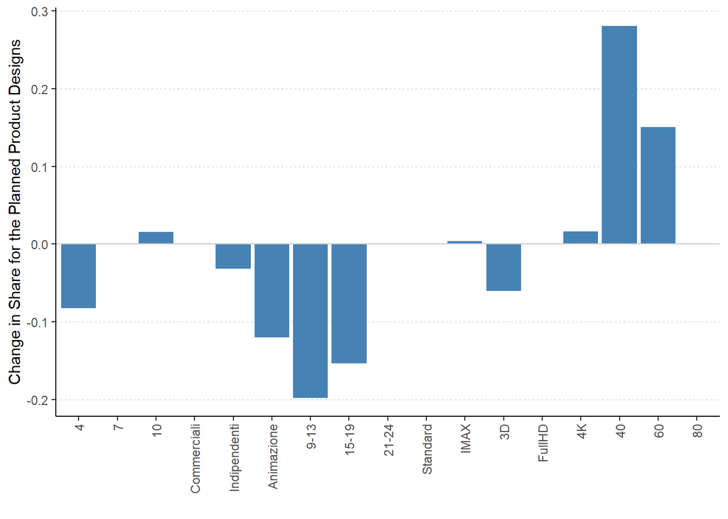

```r
# plotting
lev_order <- c("4","7","10","Commerciali","Indipendenti","Animazione",
               "9-13","15-19","21-24","Standard","IMAX","3D","FullHD","4K","40","60","80")
ggplot(data=tradeoff, aes(x=factor(level, level = lev_order), y=increase)) +
  geom_bar(stat="identity", fill="steelblue") +
  labs(x = "", y = "Change in Share for the Planned Product Designs") +
  theme_classic() +
  theme(axis.text.x = element_text(angle = 90, vjust = 0.5, hjust=1), # rotate x ticks
        text = element_text(family = "sans"), # font
        panel.grid.major.y = element_line(colour = "grey80", linetype="dashed", size = 0.01)) +
  geom_hline(yintercept = 0, colour = "grey80") # horizontal line 0
```

From the sensitivity chart we have a clear understanding of the preferences among the attributes of the profile, and how changing a level of the attribute would lead to changes in the preference shares. Indeed, the graph shows the different impact that each attribute had on the consumer’s final choice. We note that price is the attribute that had the greatest impact on the choice of cinema pass. This is followed by the time slot and the type of film. As expected, the quality of the video does not particularly influence the choice, yet there seems to be a discredit towards 3D films. This aspect would require further investigation. Similarly, the number of movies only marginally affects the choice.

# 5 Controlling for consumer Heterogeneity

Since we have a dataset with multiple responses from each respondent, we can account for the heterogeneity of the respondents using the mixed MLN. It an MLN model which allows the Beta coefficient to vary according to a-priori distribution, in our case we picked a normal distribution. It treats the respondent-level varying coefficients as realizations of a random variables and allows to identify possible niches, as we will see later.

```r
m2.rpar <- rep("n", length=length(m2$coef)) #here we are using the normal distribution
names(m2.rpar) <- names(m2$coef)
m2.rpar
```

```
##               n_film7              n_film10 tipo_filmIndipendenti
##                   "n"                   "n"                   "n"
##   tipo_filmAnimazione                h15-19                h21-24
##                   "n"                   "n"                   "n"
##         qual_cineIMAX           qual_cine3D         qual_stream4K
##                   "n"                   "n"                   "n"
##              prezzo60              prezzo80
##                   "n"                   "n"
```

In this first part we compute a mixed MNL with covariances among random effects set to zero, thus `correlation=False` in the formula.

```r
m2.mixed <- mlogit(scelta ~ n_film + tipo_film + h + qual_cine + qual_stream + prezzo |-1,
                   data = df.mlogit,
                   panel=TRUE, rpar = m2.rpar, correlation = FALSE)
summary(m2.mixed)
```

```
##
## Call:
## mlogit(formula = scelta ~ n_film + tipo_film + h + qual_cine +
##     qual_stream + prezzo | -1, data = df.mlogit, rpar = m2.rpar,
##     correlation = FALSE, panel = TRUE)
##
## Frequencies of alternatives:choice
##       1       2       3
## 0.36643 0.31363 0.31994
##
## bfgs method
## 24 iterations, 0h:0m:7s
## g'(-H)^-1g = 1.76E-07
## gradient close to zero
##
## Coefficients :
##                             Estimate  Std. Error  z-value  Pr(>|z|)
## n_film7                   0.80683984  0.17273637   4.6709 2.998e-06 ***
## n_film10                  0.83827202  0.15964853   5.2507 1.515e-07 ***
## tipo_filmIndipendenti    -0.28378384  0.12763932  -2.2233 0.0261938 *
## tipo_filmAnimazione      -1.15234766  0.15216457  -7.5730 3.642e-14 ***
## h15-19                    0.83950734  0.16279059   5.1570 2.510e-07 ***
## h21-24                    2.56412153  0.17379643  14.7536 < 2.2e-16 ***
## qual_cineIMAX             0.00077046  0.12326857   0.0063 0.9950130
## qual_cine3D              -0.47463267  0.14720067  -3.2244 0.0012624 **
## qual_stream4K             0.09241804  0.11194401   0.8256 0.4090459
## prezzo60                 -0.74897000  0.13107121  -5.7142 1.102e-08 ***
## prezzo80                 -1.73623918  0.16701228 -10.3959 < 2.2e-16 ***
## sd.n_film7                0.01853769  0.24247646   0.0765 0.9390599
## sd.n_film10               0.44622949  0.20317473   2.1963 0.0280716 *
## sd.tipo_filmIndipendenti  1.34742628  0.19214873   7.0124 2.342e-12 ***
## sd.tipo_filmAnimazione    0.91907039  0.21453885   4.2839 1.836e-05 ***
## sd.h15-19                 0.03813455  0.23193700   0.1644 0.8694023
## sd.h21-24                 1.53828923  0.17988927   8.5513 < 2.2e-16 ***
## sd.qual_cineIMAX         -0.05948528  0.24028365  -0.2476 0.8044727
## sd.qual_cine3D            0.78089767  0.18547690   4.2102 2.551e-05 ***
## sd.qual_stream4K         -0.58799586  0.17984744  -3.2694 0.0010777 **
## sd.prezzo60              -0.36236520  0.23023939  -1.5739 0.1155192
## sd.prezzo80               0.79866403  0.21731404   3.6752 0.0002377 ***
## ---
```

[output cut: 14 more lines]

```
## qual_stream4K         -Inf -0.30417914  0.0924180415  0.0924180415  0.48901522
## prezzo60              -Inf -0.99338161 -0.7489699957 -0.7489699957 -0.50455838
## prezzo80              -Inf -2.27492988 -1.7362391791 -1.7362391791 -1.19754848
##                       Max.
## n_film7                Inf
## n_film10               Inf
## tipo_filmIndipendenti  Inf
## tipo_filmAnimazione    Inf
## h15-19                 Inf
## h21-24                 Inf
## qual_cineIMAX          Inf
## qual_cine3D            Inf
## qual_stream4K          Inf
## prezzo60               Inf
## prezzo80               Inf
```

The data fitted with the mixed MNL model show almost the same part worths as the MNL model. However, in this case the `tipo_filmIndipendenti` level is somewhat more significant than in the previous model. At first glance, there is not much heterogeneity. However, the variables to watch out for would seem to be: `tipo_filmIndipendenti`,`qual_cine3D` and `qual_stream4K`. They have a standard deviation that exceeds the mean.

To better assess the level of heterogeneity of the respondents compared to the attributes levels we can obtain a visual summary of the distribution of random effects.

We distinguish the plots in homogeneous and heterogeneous distributions of random effects. We use 20% as a threshold: if at least 20% of the respondents answered differently than the others, we consider that there is heterogeneity.

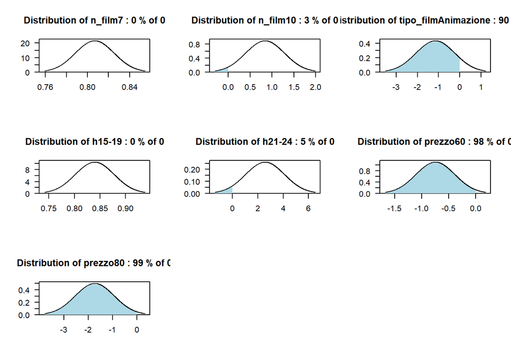

*Homogeneous distributions of random effects for the mixed MNL model with zero correlation.*

```r
plot(m2.mixed, par = c(1,2,4,5,6,10,11))
```

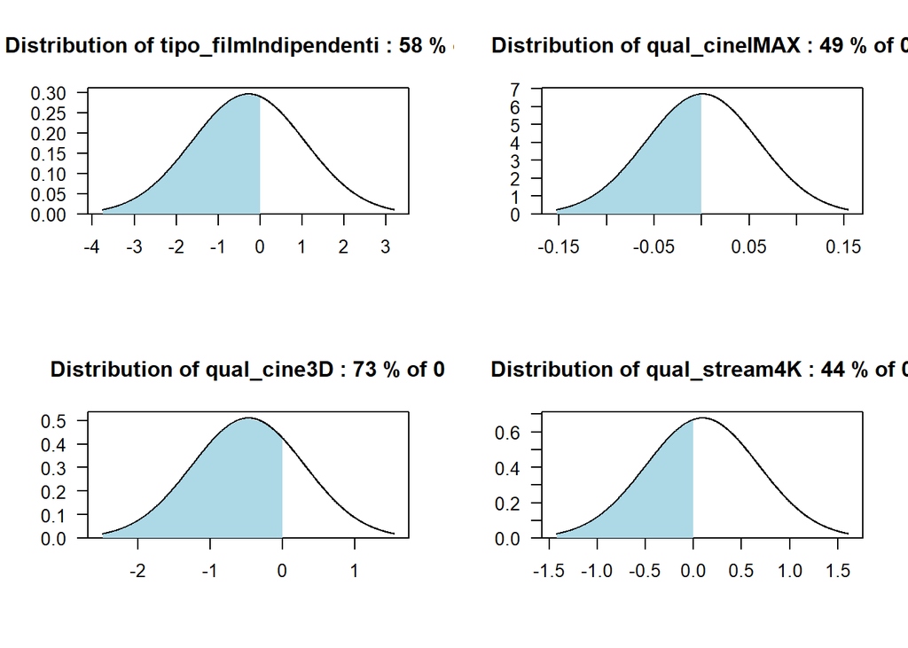

*Heterogeneous distributions of random effects for the mixed MNL model with zero correlation.*

```r
plot(m2.mixed, par = c(3,7,8,9))
```

From the above plots we can recognize how there is no heterogeneity in the distributions of the **number of movies**, the **time slot** and the **price** and `Animazione`. For the movie type `Indipendenti` it seems to be a clear distinction of respondents, almost split in two exact parts. For the distribution of `qual_cine` it seems to be niches in the `IMAX` and `3D` formats, however, we cannot assess that the `IMAX` quality is creating a niche since in the model the attribute level was not significant. On the contrary, in the case of `3D` (which is significant), the distribution of the random effects shows a very small 3rd quarter. This could be explained in two ways: (1) there is a real niche of customer that prefer 3D, (2) there were people that were forced to choose the alternative with the 3D quality of cinema since there were no desirable alternatives. To better understand this fact we would probably need more respondents and maybe change the survey design. T The distribution of `4K` follows the considerations of the `IMAX` quality: also in this case the attribute level was not significant. Lastly, the *price* distribution follows the expectations: no one seems to desire to spend more.

Finally, we tried to update the model considering the covariances between attributes, putting `Correlation = True`.

```r
m2.mixed2 <- update(m2.mixed, correlation = TRUE)
summary(m2.mixed2)
```

```
##
## Call:
## mlogit(formula = scelta ~ n_film + tipo_film + h + qual_cine +
##     qual_stream + prezzo | -1, data = df.mlogit, rpar = m2.rpar,
##     correlation = TRUE, panel = TRUE)
##
## Frequencies of alternatives:choice
##       1       2       3
## 0.36643 0.31363 0.31994
##
## bfgs method
## 67 iterations, 0h:0m:30s
## g'(-H)^-1g = 3.99E-07
## gradient close to zero
##
## Coefficients :
##                                                     Estimate  Std. Error
## n_film7                                           1.0592e+00  2.3833e-01
## n_film10                                          1.3710e+00  2.5144e-01
## tipo_filmIndipendenti                            -4.7641e-02  1.8880e-01
## tipo_filmAnimazione                              -1.8203e+00  2.3078e-01
## h15-19                                            1.4289e+00  2.6224e-01
## h21-24                                            3.5740e+00  2.7955e-01
## qual_cineIMAX                                     1.6609e-01  1.8254e-01
## qual_cine3D                                      -6.0651e-01  2.0899e-01
## qual_stream4K                                     1.5164e-01  1.4897e-01
## prezzo60                                         -6.1270e-01  1.9146e-01
## prezzo80                                         -2.1469e+00  2.3947e-01
## chol.n_film7:n_film7                              1.1758e-01  2.5296e-01
## chol.n_film7:n_film10                            -3.4619e-01  2.8751e-01
## chol.n_film10:n_film10                            1.1090e+00  2.3638e-01
## chol.n_film7:tipo_filmIndipendenti                2.4168e+00  2.4522e-01
## chol.n_film10:tipo_filmIndipendenti               5.2009e-02  2.0549e-01
## chol.tipo_filmIndipendenti:tipo_filmIndipendenti  5.5588e-01  2.1328e-01
## chol.n_film7:tipo_filmAnimazione                  9.9702e-01  2.3425e-01
## chol.n_film10:tipo_filmAnimazione                -1.6242e+00  2.5068e-01
## chol.tipo_filmIndipendenti:tipo_filmAnimazione    6.9434e-01  2.5814e-01
## chol.tipo_filmAnimazione:tipo_filmAnimazione     -1.8762e-05  1.9108e-01
## chol.n_film7:h15-19                              -2.2026e-01  2.4513e-01
## chol.n_film10:h15-19                              1.2978e+00  2.8008e-01
```

[output cut: 135 more lines]

```
## Log-Likelihood: -947.42
##
## random coefficients
##                       Min.     1st Qu.      Median        Mean    3rd Qu. Max.
## n_film7               -Inf  0.97986595  1.05917436  1.05917436  1.1384828  Inf
## n_film10              -Inf  0.58742480  1.37104430  1.37104430  2.1546638  Inf
## tipo_filmIndipendenti -Inf -1.72067834 -0.04764138 -0.04764138  1.6253956  Inf
## tipo_filmAnimazione   -Inf -3.18836443 -1.82025349 -1.82025349 -0.4521425  Inf
## h15-19                -Inf  0.01387061  1.42888923  1.42888923  2.8439079  Inf
## h21-24                -Inf  1.23839463  3.57399563  3.57399563  5.9095966  Inf
## qual_cineIMAX         -Inf -0.65974342  0.16609366  0.16609366  0.9919307  Inf
## qual_cine3D           -Inf -1.63563698 -0.60650743 -0.60650743  0.4226221  Inf
## qual_stream4K         -Inf -0.69939135  0.15164360  0.15164360  1.0026786  Inf
## prezzo60              -Inf -1.47899311 -0.61270119 -0.61270119  0.2535907  Inf
## prezzo80              -Inf -3.59824961 -2.14687583 -2.14687583 -0.6955020  Inf
```

Estimates of the attribute levels in this model are almost the same as in the previous models considered. The only difference is in the attribute level `tipo_filmIndipendenti` which is not significant. As before, we plot the distributions of random effects distinguishing between homogeneous and heterogeneous attribute levels.

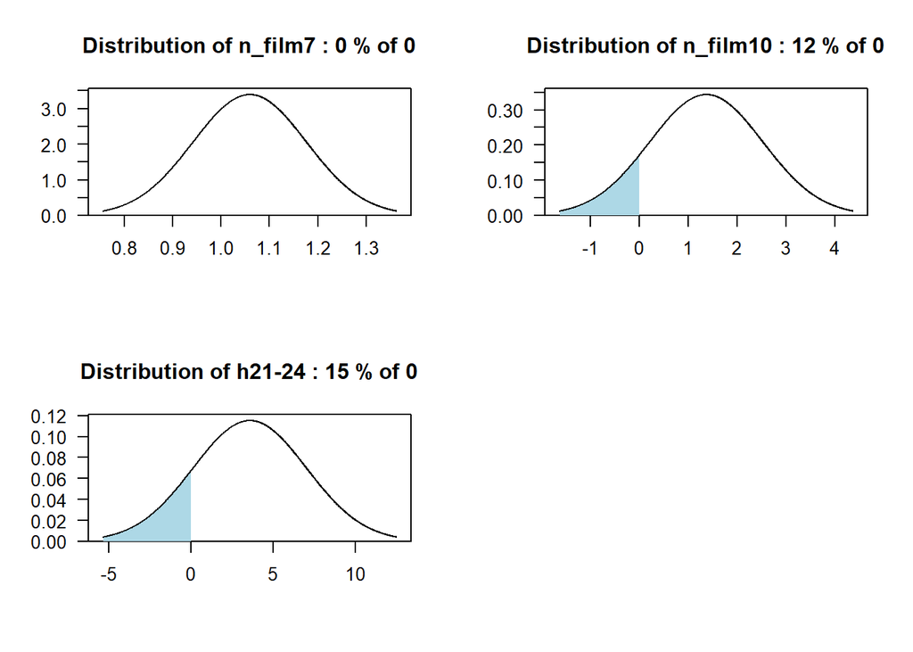

*Homogeneous distributions of random effects for the mixed MNL model with correlation.*

```r
plot(m2.mixed2, par = c(1,2,6))
```

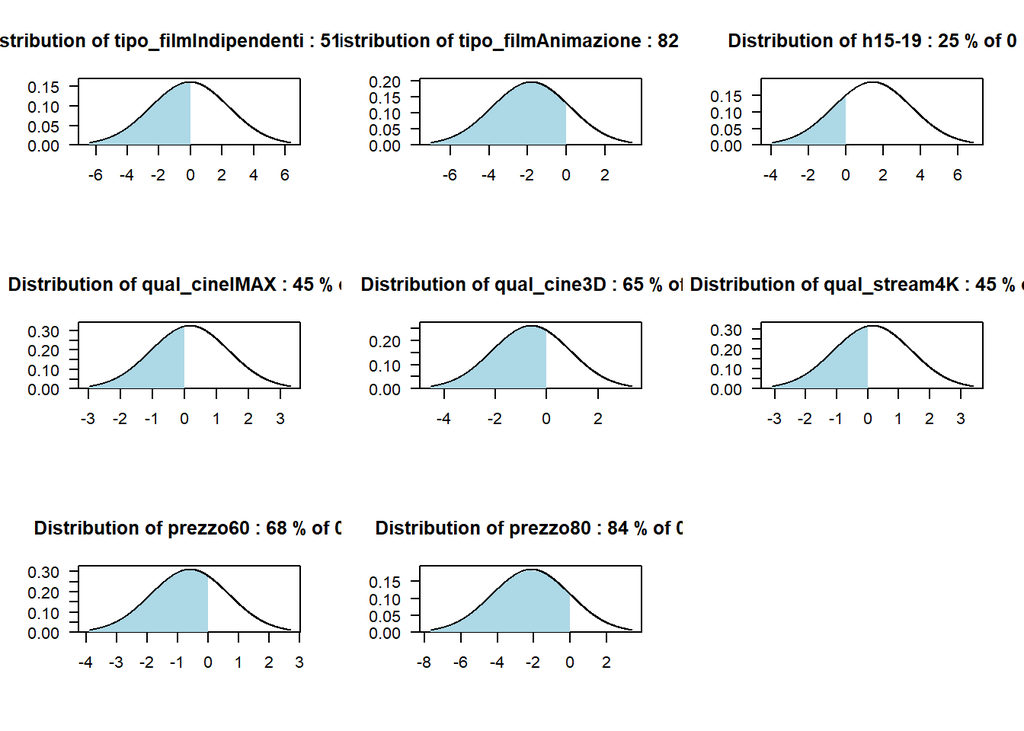

*Heterogeneous distributions of random effects for the mixed MNL model with correlation.*

```r
plot(m2.mixed2, par = c(3,4,5,7,8,9,10,11))
```

Unsurprisingly, more emphasis is placed here on heterogeneity among respondents. In this model, in fact, we note greater heterogeneity in the attribute levels referring to **time slot**, those referring to **price** and, lastly, the attribute level referring to **animation** movies.  
As far as *price* is concerned, it could be said that there are a slight but non negligible part of respondents who are less sparing in their choice of cinema passes. The preference of some of them for an *afternoon time* slot could be related to those respondents who prefer independent movies. Finally, a certain level of heterogeneity can also be seen in *animation* movies, with a niche of respondents that actually like this type of movies. No other important changes are notable in the other attribute levels.

We can also obtain the standard errors of the correlations among random effects, and hence perform significance test.

```r
summary(vcov(m2.mixed2, what = "rpar", type = "cor"))
```

```
##                                                 Estimate Std. Error z-value
## sd.n_film7                                     0.1175828  0.2529598  0.4648
## sd.n_film10                                    1.1617960  0.2462611  4.7177
## sd.tipo_filmIndipendenti                       2.4804483  0.2428484 10.2140
## sd.tipo_filmAnimazione                         2.0283643  0.2553128  7.9446
## sd.h15-19                                      2.0979097  0.3145809  6.6689
## sd.h21-24                                      3.4627672  0.3389342 10.2166
## sd.qual_cineIMAX                               1.2243879  0.2236517  5.4745
## sd.qual_cine3D                                 1.5257898  0.2582350  5.9085
## sd.qual_stream4K                               1.2617463  0.2202503  5.7287
## sd.prezzo60                                    1.2843663  0.2375997  5.4056
## sd.prezzo80                                    2.1518100  0.2628174  8.1875
## cor.n_film7:n_film10                          -0.2979784  2.1646911 -0.1377
## cor.n_film7:tipo_filmIndipendenti              0.9743392  2.9716219  0.3279
## cor.n_film10:tipo_filmIndipendenti            -0.2703169  0.4231492 -0.6388
## cor.n_film7:tipo_filmAnimazione                0.4915398  2.2954992  0.2141
## cor.n_film10:tipo_filmAnimazione              -0.9108464  0.5319589 -1.7122
## cor.tipo_filmIndipendenti:tipo_filmAnimazione  0.5388518  0.1203966  4.4756
## cor.n_film7:h15-19                            -0.1049889  2.7433492 -0.0383
## cor.n_film10:h15-19                            0.6218057  0.2028463  3.0654
## cor.tipo_filmIndipendenti:h15-19               0.0335953  0.2235873  0.1503
## cor.tipo_filmAnimazione:h15-19                -0.3592205  0.3400969 -1.0562
## cor.n_film7:h21-24                            -0.1944938  2.9541892 -0.0658
## cor.n_film10:h21-24                            0.3391264  0.2716867  1.2482
## cor.tipo_filmIndipendenti:h21-24              -0.0420225  0.2048186 -0.2052
## cor.tipo_filmAnimazione:h21-24                -0.1156320  0.2646417 -0.4369
## cor.h15-19:h21-24                              0.8841377  0.0639422 13.8271
## cor.n_film7:qual_cineIMAX                      0.3412482  1.9655863  0.1736
## cor.n_film10:qual_cineIMAX                     0.2770732  0.2951934  0.9386
## cor.tipo_filmIndipendenti:qual_cineIMAX        0.3451644  0.2619193  1.3178
## cor.tipo_filmAnimazione:qual_cineIMAX         -0.1433400  0.3601222 -0.3980
## cor.h15-19:qual_cineIMAX                       0.4164353  0.2775840  1.5002
## cor.h21-24:qual_cineIMAX                       0.0775222  0.3239753  0.2393
## cor.n_film7:qual_cine3D                        0.1866043  2.2052171  0.0846
## cor.n_film10:qual_cine3D                       0.5881124  0.2157527  2.7259
## cor.tipo_filmIndipendenti:qual_cine3D          0.2708580  0.2167748  1.2495
## cor.tipo_filmAnimazione:qual_cine3D           -0.3338515  0.3648489 -0.9150
## cor.h15-19:qual_cine3D                         0.5117973  0.2114686  2.4202
## cor.h21-24:qual_cine3D                         0.2016173  0.2876996  0.7008
## cor.qual_cineIMAX:qual_cine3D                  0.7202089  0.1515272  4.7530
```

[output cut: 81 more lines]

```
## cor.qual_cineIMAX:prezzo60                     0.070973 .
## cor.qual_cine3D:prezzo60                       0.824017
## cor.qual_stream4K:prezzo60                     0.664573
## cor.n_film7:prezzo80                           0.955317
## cor.n_film10:prezzo80                          0.583263
## cor.tipo_filmIndipendenti:prezzo80             0.765665
## cor.tipo_filmAnimazione:prezzo80               0.669196
## cor.h15-19:prezzo80                            0.528803
## cor.h21-24:prezzo80                            0.437338
## cor.qual_cineIMAX:prezzo80                     0.051173 .
## cor.qual_cine3D:prezzo80                       0.708897
## cor.qual_stream4K:prezzo80                     0.762317
## cor.prezzo60:prezzo80                         4.204e-08 ***
## ---
## Signif. codes:  0 '***' 0.001 '**' 0.01 '*' 0.05 '.' 0.1 ' ' 1
```

All these couples of attributes show a positive correlation ranging from 0.5 to 0.9. In particular, it is worth of notice that there is a significant and positive correlation between the highest quality of video, `qual_cineIMAX` and `qual_stream4K`.

To easily have an idea of the strength of correlations between variables we can plot them.

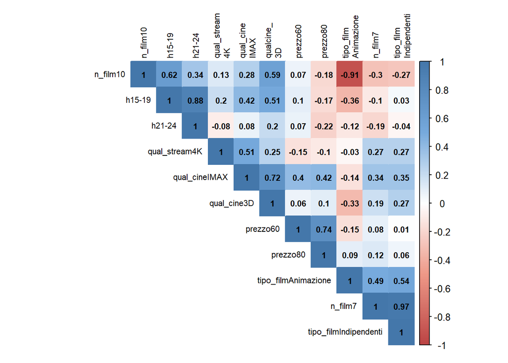

*Correlation plot of the mixed MNL model with correlation.*

```r
M <- cov2cor(cov.mlogit(m2.mixed2))

colnames(M) <- c("n_film7", "n_film10", "tipo_film\nIndipendenti", "tipo_film\nAnimazione",
                 "h15-19", "h21-24", "qual_cine\nIMAX","qualcine_\n3D", "qual_stream\n4K", "prezzo60", "prezzo80")

col <- colorRampPalette(c("#BB4444", "#EE9988", "#FFFFFF", "#77AADD", "#4477AA"))

corrplot(M, method="color", col=col(200), type="upper", order="hclust", addCoef.col = "black", # Add coefficient of correlation
         number.cex = .7, tl.col="black", tl.cex=.7, tl.srt = 90,
         diag=TRUE, mar=c(.8,0,.8,0) )
```

The plot above shows that movie `Indipendenti` is highly correlated with the 7 number of movies, while movie `Animazione` is highly negatively correlated with 10 number of movies. The explanation to this correlation may be found in the survey design. In the case of independent movies, our hypothesis is that people preferred to select the wished type of movie even if they would choose less movies. In the case of animation movies, we may assess that no one really like seeing them to the extent to have a 10 movie pass. Other relevant correlations may be the n_film10 with h15-19, which may indicate that even though the afternoon time is not quite appreciated, it is selected if a high number of movies is offered.

Since these correlations make sense and show that respondents behaved rationally, here we restrict according to the above correlation to only random parameters with significant association.

```r
m2.mixed3 <- update(m2.mixed2, correlation = c("tipo_filmIndipendenti", "tipo_filmAnimazione", "n_film10", "h15-19",
                                               "h21-24", 'qual_cine3D', 'qual_cineIMAX', 'qual_stream4K','prezzo60','prezzo80'))
```

The significant presence of random coefficients and their correlation can be further investigated using the Likelihood Ratio test between the models fitted so far.

- Fixed effects vs. uncorrelated random effects

```r
lrtest(m2, m2.mixed)
```

|  | #Df | LogLik | Df | Chisq | Pr(>Chisq) |
| --- | --- | --- | --- | --- | --- |
| 1 | 11 | -1108.927 | NA | NA | NA |
| 2 | 22 | -1042.878 | 11 | 132.0989 | 6.543268e-23 |

In this case we have enough sample evidence to reject the null hypothesis that the variances of the random effects are all equal to zero. For this reason we choose the model which considers the random effects since they are significant in explaining consumer preferences.

- Uncorrelated random effects vs. all correlated random effects

```r
lrtest(m2.mixed, m2.mixed2)
```

|  | #Df | LogLik | Df | Chisq | Pr(>Chisq) |
| --- | --- | --- | --- | --- | --- |
| 1 | 22 | -1042.8779 | NA | NA | NA |
| 2 | 77 | -947.4211 | 55 | 190.9136 | 6.731776e-17 |

Here larger model is significantly better to explain consumer preferences. It’s not reasonable to assume that the preferences for specific levels are not associated with preferences for other levels. So, we choose the model with all correlated random effects.

- Partially correlated random effects vs. all correlated random effects

```r
lrtest(m2.mixed3, m2.mixed2)
```

|  | #Df | LogLik | Df | Chisq | Pr(>Chisq) |
| --- | --- | --- | --- | --- | --- |
| 1 | 67 | -960.9729 | NA | NA | NA |
| 2 | 77 | -947.4211 | 10 | 27.10362 | 0.002507808 |

Finally, we compare the model with partially correlated random effects and the one with all correlated random effects. Also in this case the latter is significantly better than the former. So we will simulate the preference shares using the model with all correlated random effects.

## 5.1 Simulate Preference Shares

Preference shares based on the mixed MNL model are substantially the same as those we computed in the previous paragraph. The main difference is the way in which they are computed: differently from the fixed effects MNL model, indeed, here preference shares are computed for each respondent and then averaged.

```r
set.seed(5973)
predict.mixed.mnl(m2.mixed2, data=new.data)
```

|  | colMeans(shares) | n_film | tipo_film | h | qual_stream | qual_cine | prezzo |
| --- | --- | --- | --- | --- | --- | --- | --- |
| 344 | 0.20396397 | 7 | Commerciali | 21-24 | FullHD | Standard | 80 |
| 307 | 0.05117769 | 4 | Commerciali | 15-19 | 4K | 3D | 60 |
| 14 | 0.17724038 | 7 | Indipendenti | 15-19 | FullHD | Standard | 40 |
| 429 | 0.33224104 | 10 | Indipendenti | 21-24 | 4K | IMAX | 80 |
| 188 | 0.19194434 | 7 | Animazione | 21-24 | FullHD | Standard | 60 |
| 7 | 0.04343258 | 4 | Animazione | 9-13 | FullHD | Standard | 40 |

# 6 Individual-level predictors

We analyse the relationship between the individual part worths and the individual level variables. As mentioned above, our survey asked respondents for their age, gender and job. The individual level variables considered will be:

- `tipo_filmAnimazione`
- `tipo_filmIndipendenti`
- `qual_cine3D`
- `qual_cineIMAX`
- `qual_stream4K`
- `prezzo60`
- `prezzo80`

We selected these variables as they are the ones where the m2.mixed2 model detected niches. However, we have to remember that `qual_filmIndependenti`, `qual_cineIMAX` and `qual_stream4K` are not significant, so we have to be careful to assess whether there really is a niche.

In the following analysis we plot for each variable the Histograms and the Boxplots. Due to the lack of observations in some categories we make a t.test only with the variables `Lavoratore Dipendente`,`Studente`, `18-21`, `22-25` and for the genre.

We start by extracting the individual part worth from the m2.mixed2, which is the mixed model with correlation among variables, which is also the one that better assessed the presence of some niches.

```r
PW.ind <- fitted(m2.mixed2, type = "parameters")
(individual.data <- unique(df[,c(1,11,12,13)]))
```

|  | resp.id | professione | genere | età |
| --- | --- | --- | --- | --- |
| 1 | 1 | Studente | M | 22-25 |
| 28 | 2 | Studente | M | 22-25 |
| 55 | 3 | Lavoratore Dipendente | M | 26-30 |
| 82 | 4 | Lavoratore Dipendente | F | 51+ |
| 109 | 5 | Lavoratore Dipendente | M | 22-25 |
| 136 | 6 | Lavoratore Dipendente | M | 22-25 |
| 163 | 7 | Studente | M | 22-25 |
| 190 | 8 | Lavoratore Dipendente | F | 31-40 |
| 217 | 9 | Studente | F | 22-25 |
| 244 | 10 | Studente | F | 22-25 |

[output cut: 131 more lines]

```r
names(PW.ind)[1] <- "resp.id"
PW.ind <- merge(PW.ind, individual.data, by="resp.id")
head(PW.ind)
```

|  | resp.id | n_film7 | n_film10 | tipo_filmIndipendenti | tipo_filmAnimazione | h15.19 | h21.24 | qual_cineIMAX | qual_cine3D | qual_stream4K | prezzo60 | prezzo80 | professione | genere | età |
| --- | --- | --- | --- | --- | --- | --- | --- | --- | --- | --- | --- | --- | --- | --- | --- |
| 1 | 1 | 1.0154485 | 1.3782402 | -0.2933656 | -1.19018689 | 0.613091 | 2.766593 | -0.03943248 | 1.5748808 | 0.7316740 | -3.1936119 | -1.2286865 | Studente | M | 22-25 |
| 2 | 2 | 1.0088529 | 0.2387106 | -1.2697300 | -0.53111549 | -1.115291 | -1.125275 | 0.81827196 | -0.2061615 | 0.1727896 | -1.0255482 | 0.1840205 | Studente | M | 22-25 |
| 3 | 3 | 1.1402011 | 2.1773909 | 2.9620355 | -1.04562540 | 3.366451 | 5.729123 | 1.25179019 | 3.2959378 | 0.2308561 | -1.4545243 | -0.5780276 | Lavoratore Dipendente | M | 26-30 |
| 4 | 4 | 0.9873515 | 1.5856477 | -1.1141145 | -1.92225159 | 5.237461 | 12.081122 | 1.22093402 | 0.5782371 | -2.2266034 | 0.9574061 | 0.2564827 | Lavoratore Dipendente | F | 51+ |
| 5 | 5 | 1.1361650 | 1.2245099 | 2.5124880 | -0.06833712 | 4.283539 | 10.815991 | -0.49368532 | -0.7393450 | 0.2803789 | -0.2929451 | -1.6396334 | Lavoratore Dipendente | M | 22-25 |
| 6 | 6 | 0.9460689 | 2.0227694 | -2.3664019 | -3.25723729 | 1.089606 | 2.597495 | -0.47029125 | -0.5113904 | -0.2320566 | -1.4557323 | -3.9499333 | Lavoratore Dipendente | M | 22-25 |

```r
età_lav_stu <- PW.ind %>% filter(età %in% c("18-21","22-25"))
professione_lav_stu <- PW.ind %>% filter(professione %in% c("Lavoratore Dipendente","Studente"))
genere_lav_stu <- PW.ind %>% filter(genere %in% c("M","F"))
```

We start our analysis with the movie type `Animazione`, which was a significant variable in the mixed model which considers the correlations and presented heterogeneity in the distribution.

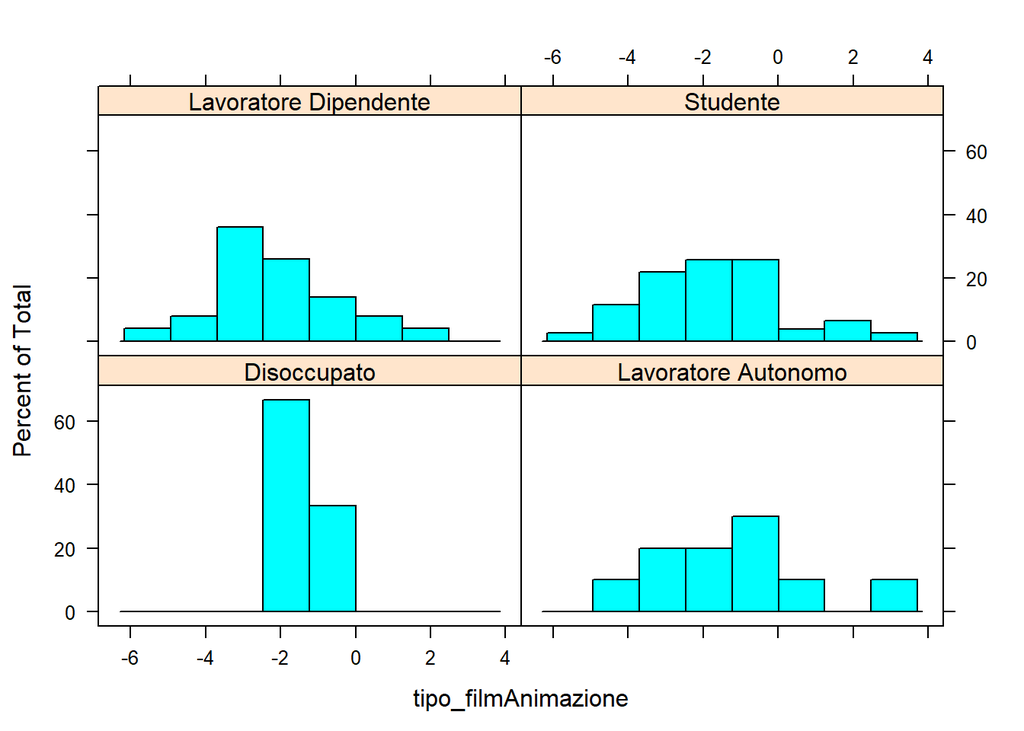

```r
set.seed(2608)

histogram(~ tipo_filmAnimazione | professione, data=PW.ind)
```

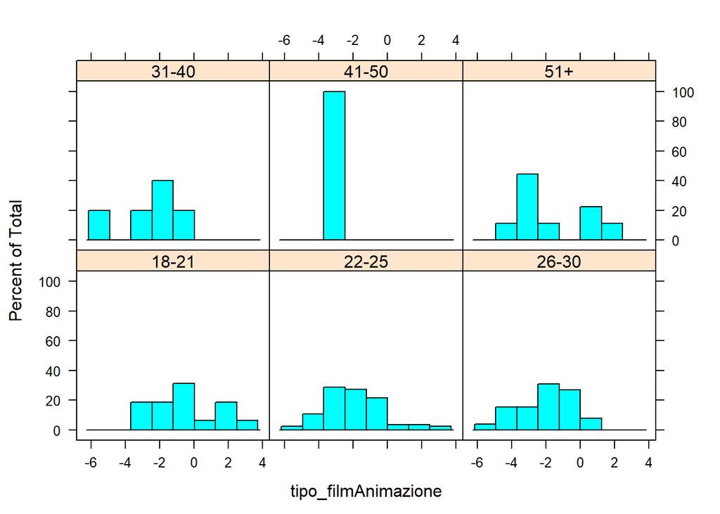

```r
histogram(~ tipo_filmAnimazione | età, data=PW.ind)
```

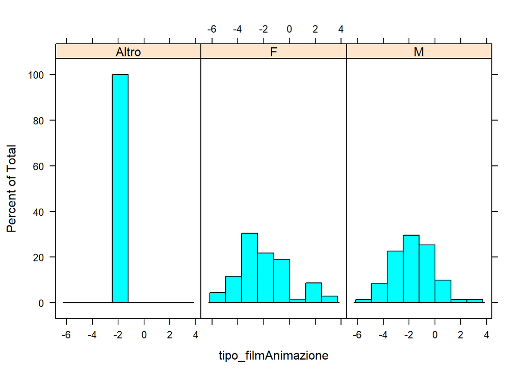

```r
histogram(~ tipo_filmAnimazione | genere, data=PW.ind)
```

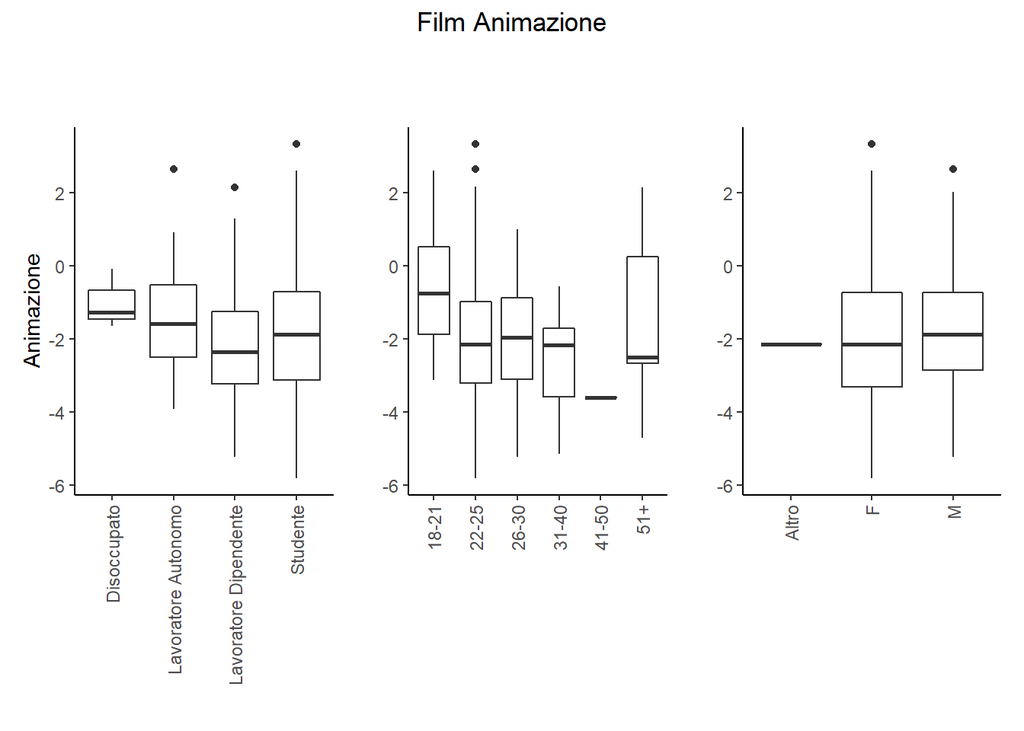

```r
p1 <- ggplot(PW.ind, aes(x=professione, y=tipo_filmAnimazione)) + geom_boxplot() +
  labs(title = "", subtitle = "",
       x = "", y = "Animazione") +
  theme_classic() +
  theme(plot.title = element_text(hjust = 0.5), # center title
        axis.text.x = element_text(angle = 90, vjust = 0.5, hjust=1),
        text = element_text(family = "sans")) # font

p2 <- ggplot(PW.ind, aes(x=età, y=tipo_filmAnimazione)) + geom_boxplot() +
  labs(title = "", subtitle = "",
       x = "", y = "") +
  theme_classic() +
  theme(plot.title = element_text(hjust = 0.5), # center title
        axis.text.x = element_text(angle = 90, vjust = 0.5, hjust=1),
        text = element_text(family = "sans")) # font

p3 <- ggplot(PW.ind, aes(x=genere, y=tipo_filmAnimazione)) + geom_boxplot() +
  labs(title = "", subtitle = "",
       x = "", y = "") +
  theme_classic() +
  theme(plot.title = element_text(hjust = 0.5), # center title
        axis.text.x = element_text(angle = 90, vjust = 0.5, hjust=1),
        text = element_text(family = "sans")) # font

pp <- p1+p2+p3
pp+ plot_annotation(
  title = 'Film Animazione',theme = theme(plot.title = element_text(hjust = 0.5)))
```

```r
#by(PW.ind$ tipo_filmAnimazione, PW.ind$professione, mean)
t.test(tipo_filmAnimazione ~ professione, data=professione_lav_stu)
```

```
##
##  Welch Two Sample t-test
##
## data:  tipo_filmAnimazione by professione
## t = -1.3071, df = 112.98, p-value = 0.1938
## alternative hypothesis: true difference in means is not equal to 0
## 95 percent confidence interval:
##  -1.0285696  0.2108555
## sample estimates:
## mean in group Lavoratore Dipendente              mean in group Studente
##                           -2.147553                           -1.738696
```

```r
t.test(tipo_filmAnimazione ~ età, data=età_lav_stu)
```

```
##
##  Welch Two Sample t-test
##
## data:  tipo_filmAnimazione by età
## t = 2.8284, df = 20.63, p-value = 0.01018
## alternative hypothesis: true difference in means is not equal to 0
## 95 percent confidence interval:
##  0.3664559 2.4103312
## sample estimates:
## mean in group 18-21 mean in group 22-25
##          -0.5910171          -1.9794106
```

```r
t.test(tipo_filmAnimazione ~ genere, data=genere_lav_stu)
```

```
##
##  Welch Two Sample t-test
##
## data:  tipo_filmAnimazione by genere
## t = -0.68438, df = 129.28, p-value = 0.495
## alternative hypothesis: true difference in means is not equal to 0
## 95 percent confidence interval:
##  -0.8082256  0.3927821
## sample estimates:
## mean in group F mean in group M
##       -1.941174       -1.733452
```

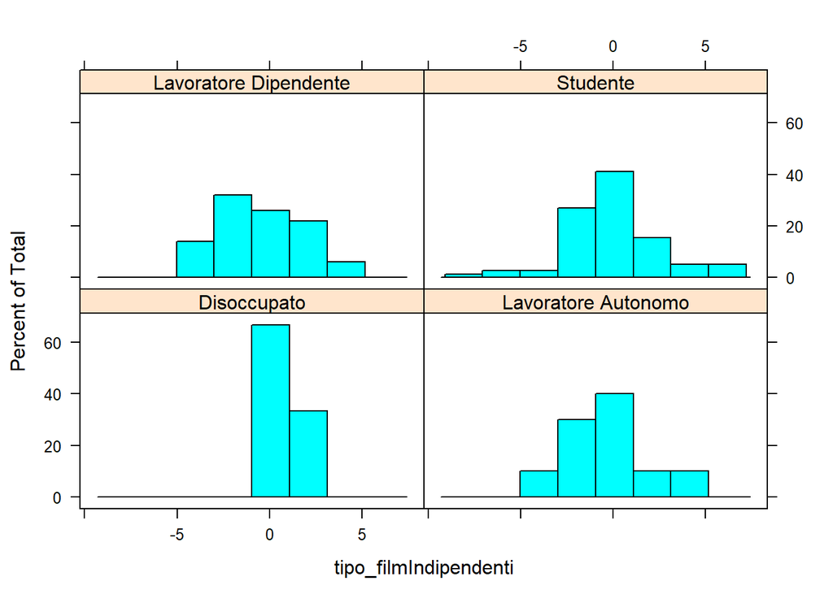

```r
set.seed(2608)

histogram(~  tipo_filmIndipendenti | professione, data=PW.ind)
```

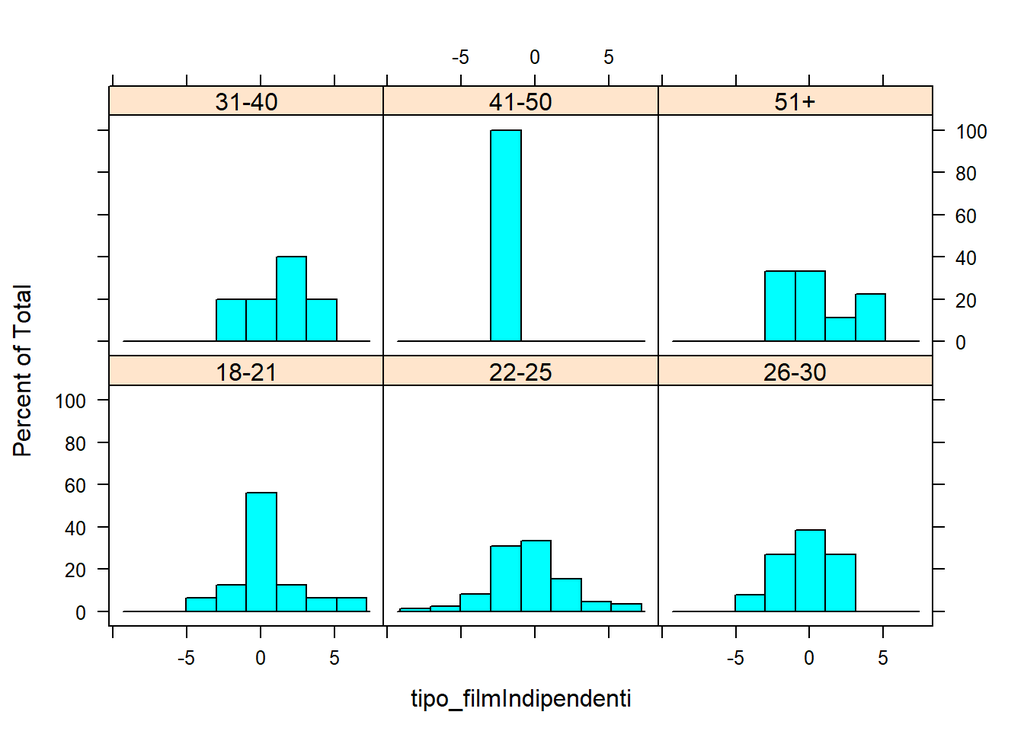

```r
histogram(~  tipo_filmIndipendenti | età, data=PW.ind)
```

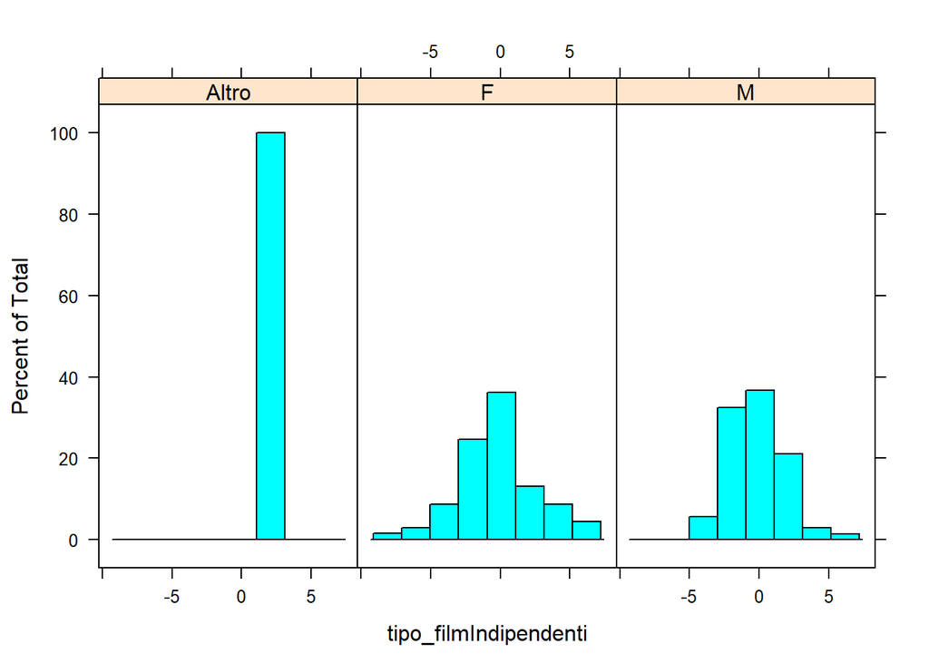

```r
histogram(~  tipo_filmIndipendenti | genere, data=PW.ind)
```

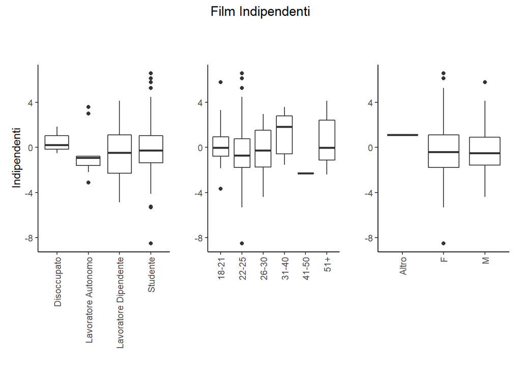

```r
p1 <- ggplot(PW.ind, aes(x=professione, y=tipo_filmIndipendenti)) + geom_boxplot() +
  labs(title = "", subtitle = "",
       x = "", y = "Indipendenti") +
  theme_classic() +
  theme(plot.title = element_text(hjust = 0.5), # center title
        axis.text.x = element_text(angle = 90, vjust = 0.5, hjust=1),
        text = element_text(family = "sans")) # font

p2 <- ggplot(PW.ind, aes(x=età, y=tipo_filmIndipendenti)) + geom_boxplot() +
  labs(title = "", subtitle = "",
       x = "", y = "") +
  theme_classic() +
  theme(plot.title = element_text(hjust = 0.5), # center title
        axis.text.x = element_text(angle = 90, vjust = 0.5, hjust=1),
        text = element_text(family = "sans")) # font

p3 <- ggplot(PW.ind, aes(x=genere, y=tipo_filmIndipendenti)) + geom_boxplot() +
  labs(title = "", subtitle = "",
       x = "", y = "") +
  theme_classic() +
  theme(plot.title = element_text(hjust = 0.5), # center title
        axis.text.x = element_text(angle = 90, vjust = 0.5, hjust=1),
        text = element_text(family = "sans")) # font

pp <- p1+p2+p3
pp+ plot_annotation(
  title = 'Film Indipendenti',theme = theme(plot.title = element_text(hjust = 0.5)))
```

```r
#by(PW.ind$ tipo_filmIndipendenti, PW.ind$professione, mean)
t.test(tipo_filmIndipendenti ~ professione, data=professione_lav_stu)
```

```
##
##  Welch Two Sample t-test
##
## data:  tipo_filmIndipendenti by professione
## t = -0.81137, df = 110.83, p-value = 0.4189
## alternative hypothesis: true difference in means is not equal to 0
## 95 percent confidence interval:
##  -1.2026822  0.5039102
## sample estimates:
## mean in group Lavoratore Dipendente              mean in group Studente
##                          -0.4547868                          -0.1054008
```

```r
t.test(tipo_filmIndipendenti ~ età, data=età_lav_stu)
```

```
##
##  Welch Two Sample t-test
##
## data:  tipo_filmIndipendenti by età
## t = 1.2619, df = 23.491, p-value = 0.2194
## alternative hypothesis: true difference in means is not equal to 0
## 95 percent confidence interval:
##  -0.4840493  2.0029201
## sample estimates:
## mean in group 18-21 mean in group 22-25
##           0.2811539          -0.4782815
```

```r
t.test(tipo_filmIndipendenti ~ genere, data=genere_lav_stu)
```

```
##
##  Welch Two Sample t-test
##
## data:  tipo_filmIndipendenti by genere
## t = -0.034837, df = 126.96, p-value = 0.9723
## alternative hypothesis: true difference in means is not equal to 0
## 95 percent confidence interval:
##  -0.8160230  0.7877883
## sample estimates:
## mean in group F mean in group M
##      -0.2628555      -0.2487381
```

In this analysis of the type of film `Independenti`, there is no particular evidence. The t.test discarded any possible difference between the groups moreover their p-values are quite high.

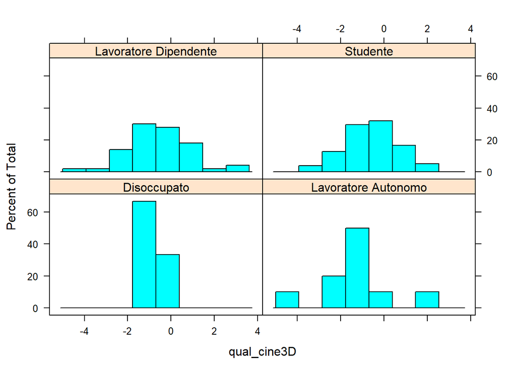

```r
set.seed(2608)

histogram(~ qual_cine3D| professione, data=PW.ind)
```

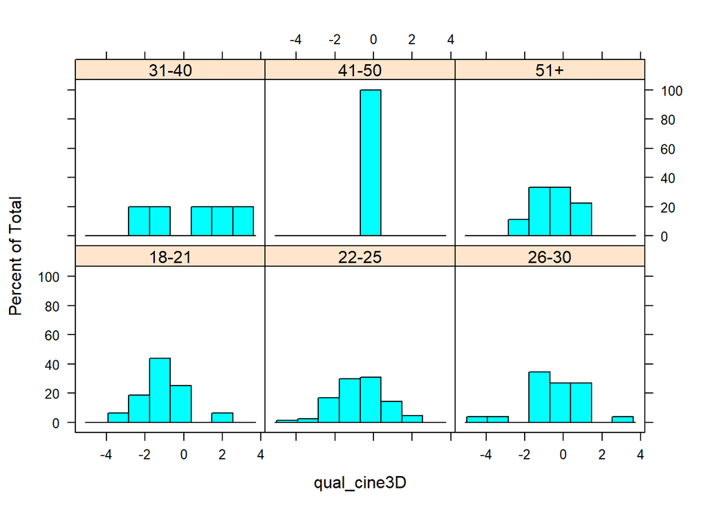

```r
histogram(~ qual_cine3D| età, data=PW.ind)
```

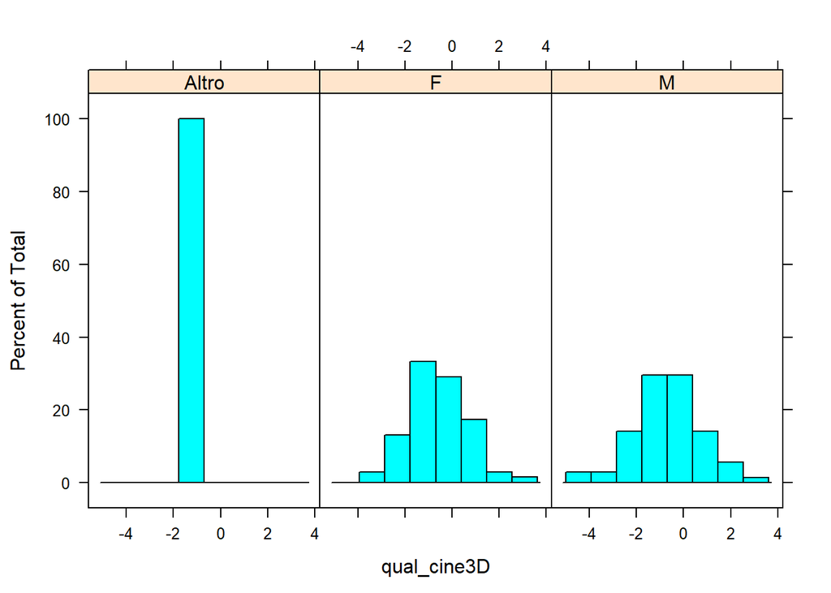

```r
histogram(~ qual_cine3D| genere, data=PW.ind)
```